# act_report

## Report: act_report

### ANALYZING AND VISUALIZING DATA

It is clearly evident that most of 'WeRateDogs' followers use iphones. Twitter for iPhone had the most tweets of 1900, followed by Twitter Web Client 28 and finally TweetDeck with 10.

Honestly, some of us could not even dare to swim, but a doggo enlighted many by standing in a pool. He trended with as much as 79515 retweets with rating of 13/10.

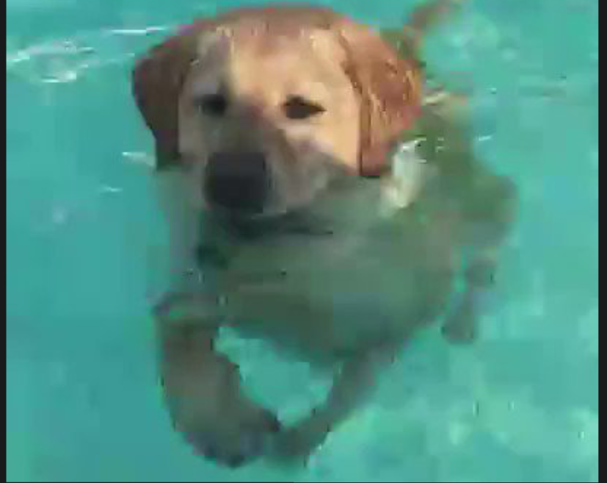

The #1 prediction for the image in that tweet was spot on with a confidence interval of approximately 82%. When the video of the Labrador Retriever swimming swiftly and then standing on water was posted at 2016-06-18 18:26:18 by Tina Conrod, it started to received hearts adding to 131075. You can check the tweet id: 744234799360020481 post by clicking the following link https://t.co/7wE9LTEXC4

Super supportive puppo participating in the Toronto #WomensMarch today won the hearts of 132810 people and a rating of 13/10. My guess is that the burner she had made her to be loved more likely by moms. Look at him, will you also not be thrilled?

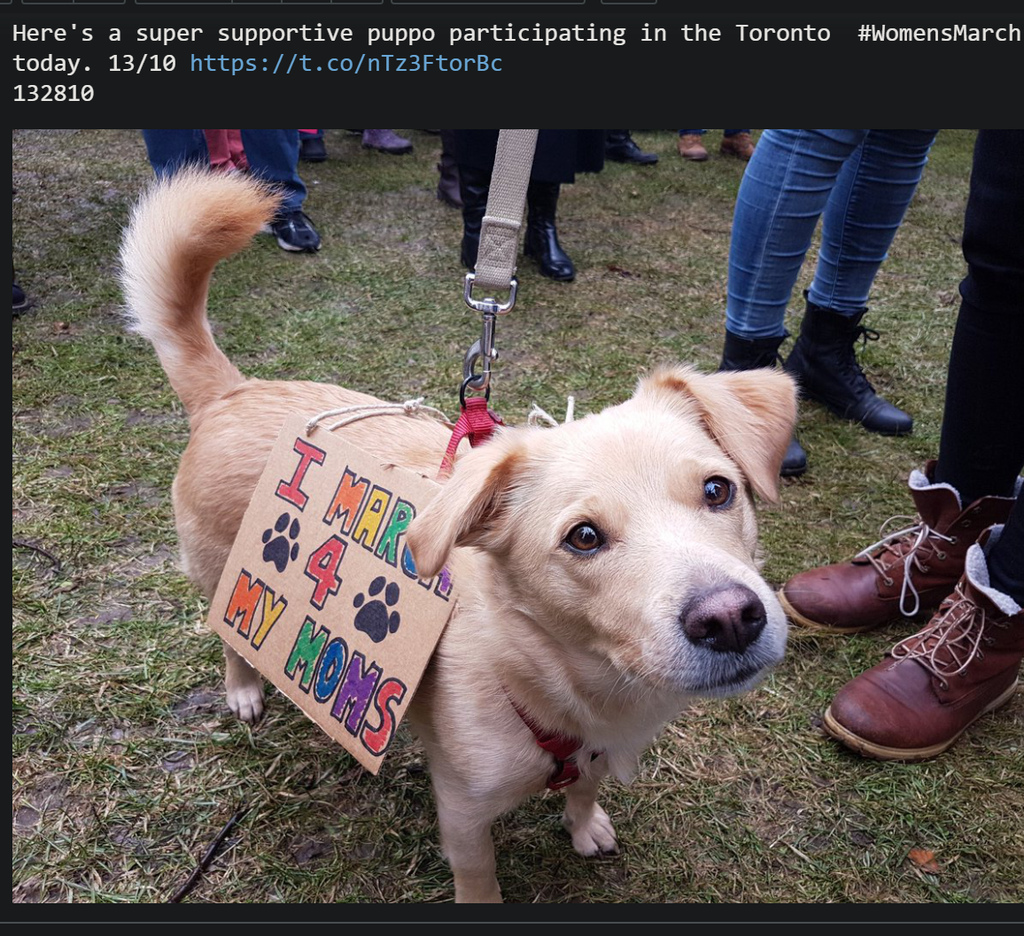

She got 48265 retweets to Toronto #womensMarch participants in return when the tweet was posted on 2017-01-21 18:26:02. Check out the favorite dog with the tweet id 822872901745569793 here https://t.co/nTz3FtorBc.

The dogs rating twitter site gained most of the followers in 2016 ending which was an increase from the previous year 2015.It was was in 2016 which a video post by Tina got retweeted highly. This must have attracted some followers who were eager to check the original tweet of the doggo swimming and then standing on a pool. In 2017, the site following clicks dropped drastically despite the tweet posted during Toronto #WomenMarch getting more likes. More amazing dog tweets including photos and videos which can attract more likes and retweets should be posted to satisfy the twitter algorithm and attract more followers.

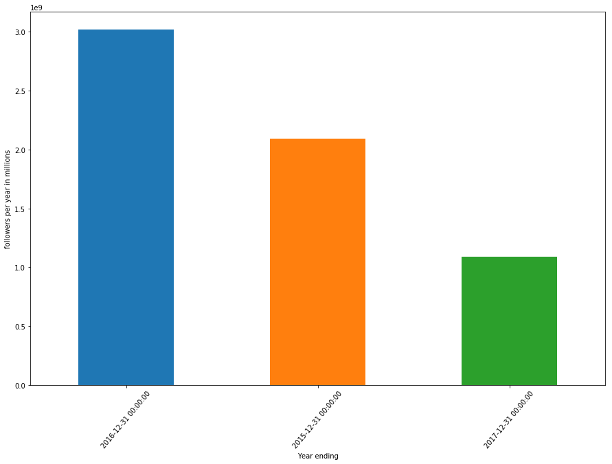